# Taller III – Análisis Factorial I: Parte común y parte propia

¿Una capacidad institucional única o dimensiones separadas? El encargo para la asignación de fondos educativos

Equipo (6): Luisa Fernández Velasco, David Santiago Lugo, Jairo Arturo Barrera, Gabriela Martínez Silva

Octubre de 2026

## Ficha técnica del caso

**Cliente:** Dirección de Cobertura y Equidad Territorial del Ministerio de Educación Nacional.  
**Decisión estratégica:** Priorizar municipios para asignar fondos extraordinarios de infraestructura (acceso) y de tutoría (permanencia).  
**Datos:** `data/raw/educacion_limpio.csv`, con 13.802 registros municipio-año (2011–2024) y las mismas 6 variables numéricas en los tres talleres: `POBLACIÓN_5_16`, `COBERTURA_NETA`, `COBERTURA_NETA_MEDIA`, `DESERCIÓN`, `APROBACIÓN` y `REPITENCIA`, estandarizadas (`scale. = TRUE`).  
**Grupo de interés (costo de error):** registros municipio-año con deserción mayor que 6,5 % o cobertura neta de 60 % o menos. Las tasas están almacenadas como proporciones: los cortes del análisis son 0,065 y 0,60.

# 1. Introducción: el encargo del Ministerio

En las fases previas (Taller I y II) construimos el resumen sintético de los municipios ($PC_1$) y exploramos el mapa de $PC_1$ contra $PC_2$. $PC_1$ guardó 30,6 % de la información, y la diferencia de escalas entre variables exigió estandarizar. En el Taller I concluimos que un solo número ordena pero no basta para decidir fondos; hoy preguntamos qué hay detrás de los indicadores y qué parte de cada uno es compartida.

Hoy el director de Cobertura nos plantea una duda estructural:

> *«En el Ministerio estamos debatiendo si fusionar los subsidios en un único fondo general de apoyo a la gestión educativa territorial. Quienes apoyan la fusión dicen que un buen municipio es bueno en todo: cobertura, deserción y retención responden a una misma capacidad institucional de fondo. Quienes se oponen afirman que el acceso y la permanencia son dos realidades distintas y que cada indicador tiene dinámicas particulares que no se comparten. ¿Miden los indicadores una sola capacidad común o son fenómenos separados?»*

Nuestra tarea hoy:

> **¿Cuántas dimensiones latentes hay detrás de los seis indicadores, y qué porcentaje de la variación de cada indicador corresponde a una capacidad común compartida frente a su dinámica propia o error de medición?**

# 2. La idea: parte común y parte propia

> ⭐ **La formulación matemática:**  
> En el análisis factorial, cada indicador estandarizado $Z_i$ se descompone en dos fuentes de variación:

> $$Z_i = \lambda_i F + u_i$$

> Donde $F$ es la dimensión o capacidad común latente (no observada directamente), $\lambda_i$ es la **carga factorial** de la variable $i$, y $u_i$ es la **parte propia o unicidad** (lo específico de ese indicador más el error de medición).  
> Al tomar varianzas (estando las variables estandarizadas con varianza 1):

> $$1 =
> \underbrace{\lambda_i^2}_{\text{Comunalidad } (h_i^2)} +
> \underbrace{\text{Var}(u_i)}_{\text{Unicidad } (u_i^2)}$$

> ⭐ **En palabras:** En el modelo de un factor, la **comunalidad** ($\lambda_i^2$) es la proporción de la varianza del indicador asociada con el factor común. Lo que sobra ($1 - \lambda_i^2$) es la **parte propia o unicidad**: variación específica que el modelo no explica y posible error de medición.

**La gran diferencia con el PCA del Taller I:** El PCA construye componentes a partir de la varianza total de las variables y no estima una unicidad para cada una. El análisis factorial modela la varianza común y separa la unicidad.

# 3. ¿Hay algo común que buscar? (Adecuación muestral KMO)

Antes de estimar factores latentes, evaluamos la adecuación de la matriz de correlaciones con el índice de Kaiser-Meyer-Olkin (KMO). Este índice orienta sobre si la estructura de correlaciones es apropiada para el análisis factorial; no sustituye la inspección del ajuste y las comunalidades.

```r
kmo <- KMO(X)

kmo_df <- data.frame(
  Variable = c("Índice general", unname(etiquetas[names(kmo$MSAi)])),
  KMO = c(kmo$MSA, as.numeric(kmo$MSAi))
)
write.csv(kmo_df, file.path(dir_tablas, "kmo.csv"), row.names = FALSE)

knitr::kable(
  kmo_df,
  digits = 3,
  format = "pipe",
  caption = "Índice KMO general e individual por variable para los indicadores educativos."
)
```

Índice KMO general e individual por variable para los indicadores educativos.

| Variable | KMO |
| --- | --- |
| Índice general | 0.504 |
| Población (5 a 16) | 0.781 |
| Cobertura neta | 0.477 |
| Cobertura media | 0.502 |
| Deserción | 0.508 |
| Aprobación | 0.527 |
| Repitencia | 0.505 |

```r
kmo_tasas <- kmo$MSAi[setdiff(names(kmo$MSAi), "POBLACIÓN_5_16")]
kmo_nivel <- ifelse(kmo$MSA >= 0.7, "bueno", ifelse(kmo$MSA >= 0.5, "apenas aceptable", "inaceptable"))
```

> ⭐ **Qué ve:** El índice KMO general es 0,50. Por indicador va de 0,48 (Cobertura neta) a 0,78 (Población (5 a 16)), y las cinco tasas educativas quedan entre 0,48 y 0,53. 1 de los 6 indicadores está por debajo de 0,5.

> ⭐ **Qué significa para el cliente:** El KMO compara la magnitud de las correlaciones observadas con la de las correlaciones parciales: valores mayores sugieren que un análisis factorial puede ser más apropiado. No es un porcentaje de varianza común ni mide por sí solo cuánto comparten los indicadores. Como referencia orientativa, valores por encima de 0,7 suelen considerarse buenos y valores por debajo de 0,5, débiles. El valor 0,50 queda «apenas aceptable», cerca del límite inferior, por lo que se interpreta el modelo con cautela, no como evidencia de que casi no exista varianza común. Se mantienen las seis variables de los Talleres I y II para facilitar la comparación; la adecuación de incluir población se evalúa con sus cargas y comunalidades, no se presupone de antemano.

> ⭐ **Qué decide él:** Seguimos con la estimación factorial, pero el Ministerio debe leer lo que sigue con cautela: la adecuación de la matriz para este análisis es limitada.

# 4. Una sola capacidad común: reparto de varianza

Ajustamos el modelo con **un solo factor** común ($k = 1$) mediante máxima verosimilitud (`fm = "ml"`).

```r
f1 <- fa(X, nfactors = 1, fm = "ml")

reparto <- data.frame(
  variable_codigo = vars,
  variable        = unname(etiquetas[vars]),
  carga           = as.numeric(f1$loadings[, 1]),
  comun           = as.numeric(f1$communality) * 100,
  propia          = as.numeric(f1$uniquenesses) * 100
)
write.csv(reparto, file.path(dir_tablas, "reparto_comun_propia.csv"), row.names = FALSE)

knitr::kable(
  reparto[, c("variable", "carga", "comun", "propia")],
  digits = c(0, 3, 1, 1),
  col.names = c("Indicador", "Carga factorial (λ)", "% Común (Comunalidad)", "% Propia (Unicidad)"),
  format = "pipe",
  caption = "Carga factorial y reparto de varianza en un modelo de un factor."
)
```

Carga factorial y reparto de varianza en un modelo de un factor.

| Indicador | Carga factorial (λ) | % Común (Comunalidad) | % Propia (Unicidad) |
| --- | --- | --- | --- |
| Población (5 a 16) | 0.053 | 0.3 | 99.7 |
| Cobertura neta | 0.588 | 34.6 | 65.4 |
| Cobertura media | 0.997 | 99.5 | 0.5 |
| Deserción | -0.225 | 5.1 | 94.9 |
| Aprobación | 0.135 | 1.8 | 98.2 |
| Repitencia | -0.046 | 0.2 | 99.8 |

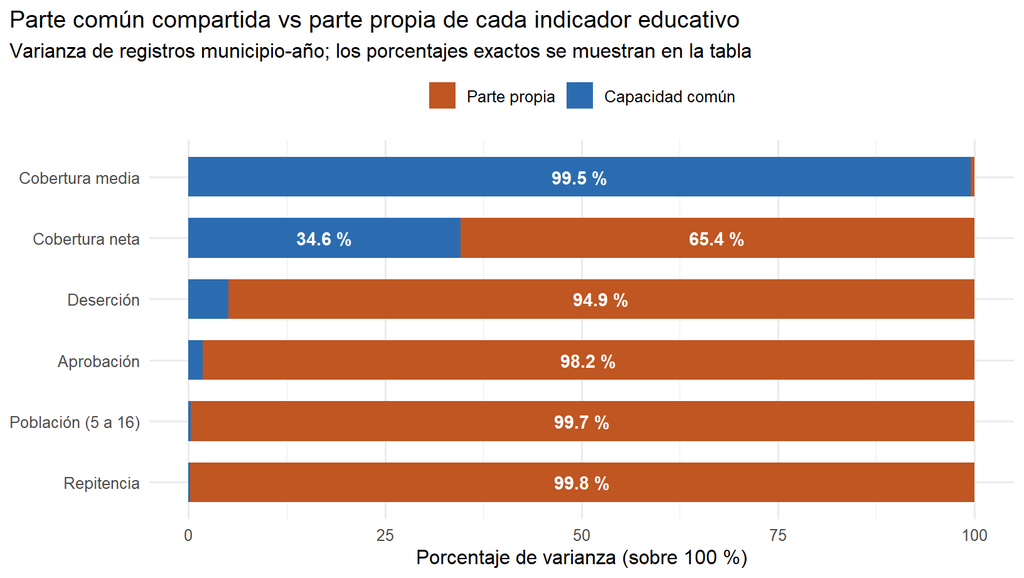

```r
fig_reparto <- file.path(dir_figuras, "comun_vs_propia.png")

p_rep <- reparto %>%
  select(variable, `Capacidad común` = comun, `Parte propia` = propia) %>%
  pivot_longer(-variable) %>%
  mutate(
    variable = factor(variable, levels = rev(reparto$variable[order(-reparto$comun)])),
    name = factor(name, levels = c("Parte propia", "Capacidad común"))
  ) %>%
  ggplot(aes(x = value, y = variable, fill = name)) +
  geom_col(width = 0.65) +
  geom_text(aes(label = ifelse(value >= 8, sprintf("%.1f %%", value), "")),
            position = position_stack(vjust = 0.5),
            color = "white", fontface = "bold", size = 3.8) +
  scale_fill_manual(values = c("Capacidad común" = "#2B6CB0", "Parte propia" = "#C05621"),
                    name = NULL) +
  theme_minimal(base_size = 12) +
  theme(legend.position = "top", plot.title.position = "plot") +
  labs(
    title = "Parte común compartida vs parte propia de cada indicador educativo",
    subtitle = "Varianza de registros municipio-año; los porcentajes exactos se muestran en la tabla",
    x = "Porcentaje de varianza (sobre 100 %)",
    y = NULL
  )

ggsave(fig_reparto, plot = p_rep, width = 8, height = 5, dpi = 150)
p_rep
```

```r
com <- setNames(reparto$comun,  reparto$variable_codigo)   # % parte común
pro <- setNames(reparto$propia, reparto$variable_codigo)   # % parte propia
lam <- setNames(reparto$carga,  reparto$variable_codigo)   # carga
mas_comun  <- names(which.max(com))
mas_propia <- names(which.max(pro))
sin_com <- c("DESERCIÓN", "APROBACIÓN", "REPITENCIA", "POBLACIÓN_5_16")
```

> ⭐ **Qué ve:** En Cobertura media, el 99,5 % de la variación entre registros viene del factor común (carga λ = 0,997); en Cobertura neta, el 34,6 %. En cambio, Deserción conserva un 94,9 % de parte propia, Aprobación un 98,2 %, Repitencia un 99,8 % y Población (5 a 16) un 99,7 %. La variable casi toda propia es Repitencia.

> ⭐ **Qué significa para el cliente:** Una carga de 0,997 es casi 1: el factor común está dominado por Cobertura media y también refleja Cobertura neta, no una capacidad educativa general. Deserción, aprobación, repitencia y población tienen como máximo 5,1 % de comunalidad en este modelo. Para Repitencia, que casi todo sea propio significa que el factor único no explica gran parte de su variación; no demuestra que el indicador sea independiente de cualquier estructura posible.

> ⭐ **Qué decide él:** Un fondo unificado que se guiara por este factor casi no vería la deserción, la aprobación ni la repitencia. Para esos frentes mira directamente cada indicador, como se concluyó en el Taller I.

# 5. ¿Alcanza con un factor? (Contraste de correlaciones y residuos)

Si una sola capacidad común explicara el sistema, la correlación entre dos variables cualesquiera debería ser aproximadamente el producto de sus cargas factoriales:

$$\text{Cor}(i, j) \approx \lambda_i
\times \lambda_j$$

Evaluamos la matriz de correlaciones observadas frente a las reproducidas por el factor y calculamos los errores residuales.

```r
R_obs <- cor(X)
L <- as.numeric(f1$loadings[, 1])
names(L) <- vars

error_mat <- R_obs - outer(L, L)
diag(error_mat) <- 0

# Pareja con mayor residuo
max_err <- max(abs(error_mat))
idx_max <- which(abs(error_mat) == max_err, arr.ind = TRUE)[1, ]
var1_max <- vars[idx_max[1]]
var2_max <- vars[idx_max[2]]

residuos_df <- as.data.frame(as.table(error_mat)) %>%
  filter(as.character(Var1) < as.character(Var2)) %>%
  rename(Variable1 = Var1, Variable2 = Var2, Residuo = Freq) %>%
  mutate(
    Variable1 = etiquetas[as.character(Variable1)],
    Variable2 = etiquetas[as.character(Variable2)],
    Residuo = round(Residuo, 3)
  ) %>%
  arrange(desc(abs(Residuo)))

cor_obs <- R_obs["DESERCIÓN", "APROBACIÓN"]
cor_rep <- unname(L["DESERCIÓN"] * L["APROBACIÓN"])
cor_res <- cor_obs - cor_rep

cn_obs <- R_obs["COBERTURA_NETA", "COBERTURA_NETA_MEDIA"]
cn_rep <- unname(L["COBERTURA_NETA"] * L["COBERTURA_NETA_MEDIA"])

n_parejas   <- choose(ncol(X), 2)
n_residuo10 <- sum(abs(error_mat[upper.tri(error_mat)]) > 0.10)
alcanza_una <- max_err < 0.10   # regla: una habilidad alcanza si ningún error pasa de 0,10

write.csv(residuos_df, file.path(dir_tablas, "residuos_correlaciones.csv"), row.names = FALSE)

knitr::kable(
  head(residuos_df, 8),
  format = "pipe",
  caption = "Mayores discrepancias (residuos) entre la correlación observada y la reproducida por el modelo de 1 factor."
)
```

Mayores discrepancias (residuos) entre la correlación observada y la reproducida por el modelo de 1 factor.

| Variable1 | Variable2 | Residuo |
| --- | --- | --- |
| Aprobación | Deserción | -0.499 |
| Aprobación | Repitencia | -0.278 |
| Cobertura neta | Deserción | 0.127 |
| Deserción | Repitencia | 0.077 |
| Aprobación | Cobertura neta | -0.071 |
| Cobertura neta | Repitencia | -0.067 |
| Cobertura neta | Población (5 a 16) | 0.015 |
| Aprobación | Población (5 a 16) | -0.011 |

> ⭐ **Qué ve:** La correlación observada entre Deserción y Aprobación es -0,530; el producto de sus cargas da -0,030 y el residuo es -0,499. En cambio, para Cobertura neta y Cobertura media la observada es 0,587 y el producto de cargas 0,587. De las 15 parejas, 3 tienen un error mayor que 0,10; el más grande es 0,499, entre Aprobación y Deserción.

> ⭐ **Qué significa para el cliente:** El mayor residuo es grande frente al umbral descriptivo de 0,10: el modelo de un factor no reproduce varias relaciones observadas. En particular, la relación entre deserción y aprobación no queda bien explicada por el factor. El límite de 0,10 es una referencia práctica para esta lectura, no una prueba estadística universal.

> ⭐ **Qué decide él:** No puede sostener que un solo índice resuma los indicadores; se prueba con dos factores (sección 6).

# 6. ¿Y si le pedimos dos factores?

Para explorar si la estructura es más compleja, usamos el análisis paralelo como guía para el número de factores y comparamos soluciones de uno y dos factores. El análisis paralelo sugiere tres factores en los registros municipio-año; sin embargo, con seis variables una solución de tres factores tiene cero grados de libertad y queda saturada, por lo que no permite evaluar su ajuste. La solución de dos factores que sigue es una exploración interpretable, no una demostración de que haya exactamente dos dimensiones.

```r
set.seed(20261023)
pa_registros <- fa.parallel(X, fa = "fa", fm = "ml", n.iter = 100, plot = FALSE)
```

```
## Parallel analysis suggests that the number of factors =  3  and the number of components =  NA
```

```r
nf_pa_registros <- pa_registros$nfact

f2 <- fa(X, nfactors = 2, fm = "ml", rotate = "oblimin")
f3_diagnostico <- fa(X, nfactors = 3, fm = "ml", rotate = "oblimin")
gl_f3 <- f3_diagnostico$dof

clave_municipio <- interaction(educ$DEPARTAMENTO, educ$MUNICIPIO, drop = TRUE)
X_municipio <- aggregate(X, by = list(clave = clave_municipio), FUN = mean)
X_municipio$clave <- NULL
kmo_municipio <- KMO(X_municipio)
set.seed(20261023)
pa_municipios <- fa.parallel(X_municipio, fa = "fa", fm = "ml",
                            n.iter = 100, plot = FALSE)
```

```
## Parallel analysis suggests that the number of factors =  2  and the number of components =  NA
```

```r
f2_municipio <- fa(X_municipio, nfactors = 2, fm = "ml", rotate = "oblimin")

ajuste_modelos <- data.frame(
  Modelo = c("1 factor", "2 factores", "3 factores"),
  Grados_libertad = c(f1$dof, f2$dof, gl_f3),
  RMSR = c(f1$rms, f2$rms, f3_diagnostico$rms)
)

cargas_f2 <- as.data.frame(unclass(f2$loadings))
colnames(cargas_f2) <- c("Factor 1", "Factor 2")
cargas_f2$Variable <- unname(etiquetas[rownames(cargas_f2)])
cargas_f2 <- cargas_f2[, c("Variable", "Factor 1", "Factor 2")]

comun_comp <- data.frame(
  Variable = unname(etiquetas[vars]),
  `Comunalidad 1 Factor (%)` = round(as.numeric(f1$communality[vars]) * 100, 1),
  `Comunalidad 2 Factores (%)` = round(as.numeric(f2$communality[vars]) * 100, 1),
  check.names = FALSE
)

phi_12 <- f2$Phi[1, 2]

cg  <- unclass(f2$loadings)[vars, ]
v_f1 <- vars[which.max(abs(cg[, 1]))]
v_f2 <- vars[which.max(abs(cg[, 2]))]
seg_f1 <- names(sort(abs(cg[, 1]), decreasing = TRUE))[2]
seg_f2 <- names(sort(abs(cg[, 2]), decreasing = TRUE))[2]
cm1 <- setNames(as.numeric(f1$communality[vars]) * 100, vars)
cm2 <- setNames(as.numeric(f2$communality[vars]) * 100, vars)
r_vv <- cor(X[[v_f1]], X[[v_f2]])
cargas_sensibilidad <- data.frame(
  Variable = unname(etiquetas[vars]),
  `Factor 1 (registros municipio-año)` = unclass(f2$loadings)[vars, 1],
  `Factor 2 (registros municipio-año)` = unclass(f2$loadings)[vars, 2],
  `Factor 1 (perfiles municipales)` = unclass(f2_municipio$loadings)[vars, 1],
  `Factor 2 (perfiles municipales)` = unclass(f2_municipio$loadings)[vars, 2],
  check.names = FALSE
)

lm2 <- unclass(f2_municipio$loadings)[vars, ]
col_des <- which.max(abs(lm2["DESERCIÓN", ]))
col_apr <- which.max(abs(lm2["APROBACIÓN", ]))
dom_mun <- vars[which.max(abs(lm2[, col_des]))]
opuestos_reg <- sign(cg["DESERCIÓN", 2]) != sign(cg["APROBACIÓN", 2])
opuestos_mun <- sign(lm2["DESERCIÓN", col_des]) != sign(lm2["APROBACIÓN", col_des])
unic_min <- 100 * min(f2$uniquenesses)
```

Hay cargas casi iguales a 1 (la unicidad mínima es 0,5 %), señal de una solución en el límite y, por tanto, inestable: al promediar por municipio, el indicador dominante del segundo factor pasa de Aprobación a Deserción. Lo que se mantiene en las dos soluciones es que deserción y aprobación entran con signo contrario; lo que no se mantiene es cuál de las dos pesa más.

```r
knitr::kable(
  cargas_f2,
  digits = 3,
  format = "pipe",
  caption = "Cargas factoriales del modelo de 2 factores con rotación oblicua oblimin."
)
```

Cargas factoriales del modelo de 2 factores con rotación oblicua oblimin.

|  | Variable | Factor 1 | Factor 2 |
| --- | --- | --- | --- |
| POBLACIÓN_5_16 | Población (5 a 16) | 0.055 | -0.011 |
| COBERTURA_NETA | Cobertura neta | 0.598 | -0.065 |
| COBERTURA_NETA_MEDIA | Cobertura media | 0.996 | 0.014 |
| DESERCIÓN | Deserción | -0.146 | -0.513 |
| APROBACIÓN | Aprobación | -0.019 | 1.000 |
| REPITENCIA | Repitencia | -0.002 | -0.284 |

```r
knitr::kable(
  comun_comp,
  digits = 1,
  format = "pipe",
  caption = "Comparación de comunalidades (% de varianza explicada) entre el modelo de 1 factor y el de 2 factores."
)
```

Comparación de comunalidades (% de varianza explicada) entre el modelo de 1 factor y el de 2 factores.

| Variable | Comunalidad 1 Factor (%) | Comunalidad 2 Factores (%) |
| --- | --- | --- |
| Población (5 a 16) | 0.3 | 0.3 |
| Cobertura neta | 34.6 | 35.1 |
| Cobertura media | 99.5 | 99.5 |
| Deserción | 5.1 | 30.6 |
| Aprobación | 1.8 | 99.5 |
| Repitencia | 0.2 | 8.1 |

```r
knitr::kable(
  ajuste_modelos,
  digits = 3,
  format = "pipe",
  caption = paste0("Diagnóstico descriptivo del ajuste; análisis paralelo en registros: ", nf_pa_registros, " factores sugeridos.")
)
```

Diagnóstico descriptivo del ajuste; análisis paralelo en registros: 3 factores sugeridos.

| Modelo | Grados_libertad | RMSR |
| --- | --- | --- |
| 1 factor | 9 | 0.155 |
| 2 factores | 4 | 0.037 |
| 3 factores | 0 | 0.000 |

```r
knitr::kable(
  cargas_sensibilidad,
  digits = 3,
  format = "pipe",
  caption = "Sensibilidad de las cargas oblicuas al promediar registros por departamento y municipio. La orientación y el orden de factores pueden cambiar entre soluciones."
)
```

Sensibilidad de las cargas oblicuas al promediar registros por departamento y municipio. La orientación y el orden de factores pueden cambiar entre soluciones.

|  | Variable | Factor 1 (registros municipio-año) | Factor 2 (registros municipio-año) | Factor 1 (perfiles municipales) | Factor 2 (perfiles municipales) |
| --- | --- | --- | --- | --- | --- |
| POBLACIÓN_5_16 | Población (5 a 16) | 0.055 | -0.011 | 0.070 | 0.014 |
| COBERTURA_NETA | Cobertura neta | 0.598 | -0.065 | 0.712 | 0.198 |
| COBERTURA_NETA_MEDIA | Cobertura media | 0.996 | 0.014 | 0.972 | -0.082 |
| DESERCIÓN | Deserción | -0.146 | -0.513 | -0.002 | 0.997 |
| APROBACIÓN | Aprobación | -0.019 | 1.000 | 0.117 | -0.450 |
| REPITENCIA | Repitencia | -0.002 | -0.284 | -0.425 | 0.038 |

> ⭐ **Qué ve:**
> - El **Factor 1** carga sobre Cobertura media (0,996) y, mucho menos, sobre Cobertura neta (0,598).
> - El **Factor 2** carga sobre Aprobación (1,000) y, mucho menos, sobre Deserción (-0,513).
> - Los dos factores van juntos $\Phi_{1,2} =$ 0,14; la correlación directa entre Cobertura media y Aprobación es 0,13.
> - La parte común de Aprobación pasa de 1,8 % a 99,5 %, la de Deserción de 5,1 % a 30,6 %, y la de Repitencia de 0,2 % a 8,1 %.

> ⭐ **Qué significa para el cliente:** El primer factor está dominado por Cobertura media (carga 0,996), con una carga secundaria de 0,598 en Cobertura neta; el segundo está dominado por Aprobación (carga 1,000), y también recoge una asociación con Deserción (carga -0,513). Por tanto, no se deben describir como dos indicadores aislados: las cargas restantes y las comunalidades muestran qué otras variables contribuyen. Aun con dos factores, Deserción conserva 69,4 % de parte propia, Repitencia 91,9 % y Población (5 a 16) 99,7 %; los factores se correlacionan (0,14). Las etiquetas «acceso» y «permanencia» serían interpretaciones nuestras, no resultados directos del análisis.

> El análisis paralelo sugiere 3 factores para los registros municipio-año. La solución de tres factores tiene 0 grados de libertad y queda saturada: un ajuste casi perfecto en ese caso no sirve para probar que tres factores sean correctos. En consecuencia, los criterios no fijan un número definitivo de dimensiones; la solución de dos factores se usa para explorar patrones, con cautela.

> ⭐ **Qué decide él:** Puede mantener separados el fondo de infraestructura (cobertura) y el de tutorías (aprobación y deserción), pero la razón es que cada fondo se guía por sus propios indicadores y no porque el análisis haya encontrado dos capacidades. Cada fondo se decide mirando directamente sus indicadores.

# 7. ¿En qué se diferencia del resumen PCA (Taller I)?

```r
pca_res <- prcomp(X, center = TRUE, scale. = TRUE)

var_pca1 <- (pca_res$sdev[1]^2 / ncol(X)) * 100
var_fa1  <- (sum(f1$communality) / ncol(X)) * 100
var_fa2  <- (sum(f2$communality) / ncol(X)) * 100
```

| Criterio comparativo | Resumen PCA ($PC_1$, Taller I) | Capacidad Común ($F_1$, Factorial I) | Dos Factores ($F_1$ y $F_2$, Factorial I) |
| --- | --- | --- | --- |
| **Objetivo central** | Maximizar la separación global entre municipios | Identificar la varianza compartida latente | Separar dimensiones que pueden asociarse (rotación oblicua) |
| **Tratamiento de la parte propia** | Incluye varianza total en la construcción de los componentes; no estima una unicidad por variable | Estima varianza común y unicidades | Estima comunalidades y unicidades para la solución de dos factores |
| **Varianza retenida / explicada** | 30,6 % de la varianza total | Comunalidad media: 23,6 % de la varianza total estandarizada | Comunalidad media: 45,5 % de la varianza total estandarizada |
| **Pregunta de política pública** | ¿Con qué índice sintético rankeo los municipios? | ¿Existe una sola capacidad institucional compartida? | ¿Cuántos fondos o programas especializados se sostienen? |

> ⭐ **Qué ve:** El primer componente del PCA explica 30,6 % de la varianza total. En los modelos factoriales, la comunalidad media es 23,6 % con un factor y 45,5 % con dos factores.

> ⭐ **Qué significa para el cliente:** Son medidas de objetivos distintos: el PCA resume la varianza total en componentes, mientras que el análisis factorial estima la parte común y deja unicidades específicas. La diferencia de 7,0 puntos entre esos porcentajes **no** equivale a la varianza propia capturada por el PCA. En los modelos factoriales, la parte no común media es 76,4 % con un factor y 54,5 % con dos. Ningún método es mejor por esa comparación; responden preguntas distintas.

> ⭐ **Qué decide él:** Para ordenar registros puede usarse $PC_1$ (Taller I); para orientar cada fondo, conviene evaluar sus indicadores directamente. El análisis factorial muestra qué parte de su variación queda explicada por los factores explorados, pero no valida por sí mismo una regla de asignación.

# 8. El costo para el Ministerio: casos críticos omitidos con una sola dimensión

Comparamos el grupo de interés definido en la ficha —deserción mayor que 6,5 % o cobertura neta de 60 % o menos— con los registros seleccionados por el 20 % de puntajes más bajos del factor único. Además de los dos criterios por separado, mostramos su unión para contar una sola vez a cada registro que cumpla al menos uno. Estos son registros municipio-año, no municipios únicos.

```r
f1_scores <- fa(X, nfactors = 1, fm = "ml", scores = "regression")
score_f1 <- as.numeric(f1_scores$scores[, 1])
if (cor(score_f1, X[["COBERTURA_NETA_MEDIA"]]) < 0) score_f1 <- -score_f1

# Una puntuación baja representa peor posición en el factor dominado por cobertura.
f1_peor <- score_f1 <= quantile(score_f1, 0.20)

crit_desercion <- X[["DESERCIÓN"]] > 0.065
crit_cobertura <- X[["COBERTURA_NETA"]] <= 0.60
crit_cualquiera <- crit_desercion | crit_cobertura
cohortes_criticas <- list(
  "Deserción > 6,5 %" = crit_desercion,
  "Cobertura neta ≤ 60 %" = crit_cobertura,
  "Cumple al menos un criterio" = crit_cualquiera
)

costo_politica <- do.call(rbind, lapply(names(cohortes_criticas), function(nombre) {
  critico <- cohortes_criticas[[nombre]]
  n_criticos <- sum(critico)
  n_atendidos <- sum(critico & f1_peor)
  n_omitidos <- sum(critico & !f1_peor)
  data.frame(
    Criterio = nombre,
    Registros_criticos = n_criticos,
    Capturados_F1 = n_atendidos,
    Omitidos_F1 = n_omitidos,
    Porcentaje_omitido = round(100 * n_omitidos / n_criticos, 1)
  )
}))

n_solapados <- sum(crit_desercion & crit_cobertura)
n_priorizados_f1 <- sum(f1_peor)
write.csv(costo_politica, file.path(dir_tablas, "costo_factor.csv"), row.names = FALSE)

omitidos_desercion <- costo_politica$Porcentaje_omitido[1]
omitidos_cobertura <- costo_politica$Porcentaje_omitido[2]
omitidos_union <- costo_politica$Porcentaje_omitido[3]
casos_union <- costo_politica$Registros_criticos[3]
omitidos_union_n <- costo_politica$Omitidos_F1[3]
```

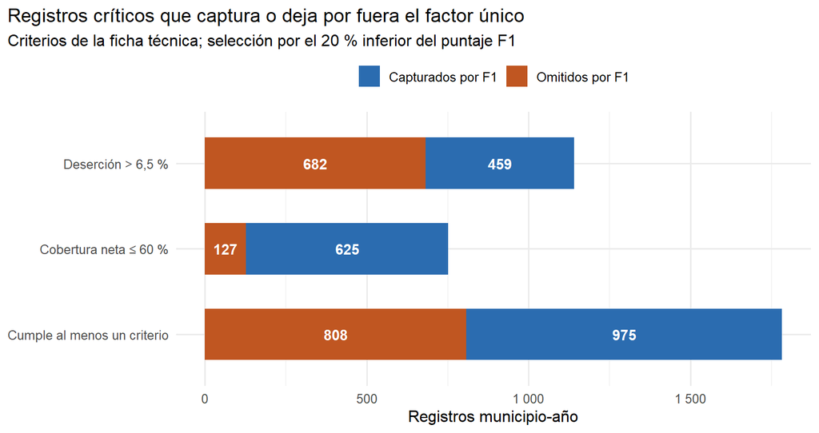

```r
fig_costo <- file.path(dir_figuras, "costo_factor.png")

p_costo <- costo_politica %>%
  select(Criterio, `Capturados por F1` = Capturados_F1, `Omitidos por F1` = Omitidos_F1) %>%
  pivot_longer(-Criterio) %>%
  mutate(
    Criterio = factor(Criterio, levels = rev(costo_politica$Criterio)),
    name = factor(name, levels = c("Capturados por F1", "Omitidos por F1"))
  ) %>%
  ggplot(aes(x = value, y = Criterio, fill = name)) +
  geom_col(width = 0.6) +
  geom_text(aes(label = miles(value)),
            position = position_stack(vjust = 0.5),
            color = "white", fontface = "bold", size = 3.8) +
  scale_fill_manual(values = c("Capturados por F1" = "#2B6CB0", "Omitidos por F1" = "#C05621"),
                    name = NULL) +
  scale_x_continuous(labels = miles) +
  theme_minimal(base_size = 12) +
  theme(legend.position = "top", plot.title.position = "plot") +
  labs(
    title = "Registros críticos que captura o deja por fuera el factor único",
    subtitle = "Criterios de la ficha técnica; selección por el 20 % inferior del puntaje F1",
    x = "Registros municipio-año",
    y = NULL
  )

ggsave(fig_costo, plot = p_costo, width = 8, height = 4.5, dpi = 150)
p_costo
```

```r
knitr::kable(
  costo_politica,
  format = "pipe",
  col.names = c("Criterio crítico", "Registros críticos", "Capturados por F1", "Omitidos por F1", "% omitido"),
  format.args = list(big.mark = ".", decimal.mark = ","),
  caption = paste0("Casos con los umbrales declarados en la ficha; el 20 % inferior de F1 selecciona ", miles(n_priorizados_f1), " registros.")
)
```

Casos con los umbrales declarados en la ficha; el 20 % inferior de F1 selecciona 2 761 registros.

| Criterio crítico | Registros críticos | Capturados por F1 | Omitidos por F1 | % omitido |
| --- | --- | --- | --- | --- |
| Deserción > 6,5 % | 1.141 | 459 | 682 | 59,8 |
| Cobertura neta ≤ 60 % | 752 | 625 | 127 | 16,9 |
| Cumple al menos un criterio | 1.783 | 975 | 808 | 45,3 |

> ⭐ **Qué ve:** De los 1 141 registros con deserción superior a 6,5 %, F1 omite 682 (59,8 %). Entre los 752 registros con cobertura neta de 60 % o menos, omite 127 (16,9 %). La unión contiene 1 783 registros —110 cumplen ambos criterios— y F1 deja por fuera 808 (45,3 %).

> ⭐ **Qué significa para el cliente:** Son omisiones bajo estos umbrales concretos, no bajo un corte percentil de cada indicador. Si el Ministerio priorizara únicamente el 20 % inferior de F1, quedarían fuera 45,3 de cada 100 registros que cumplen al menos uno de los criterios. La selección es exploratoria y no representa una regla presupuestal validada.

> ⭐ **Qué decide él:** Para el fondo de tutorías, el criterio tiene que ser deserción, aprobación y repitencia directamente, no el factor común.

# 9. Qué no es una dimensión latente común

- **No es una entidad observable:** Se deduce de la covarianza compartida. Ningún sensor mide directamente la “capacidad institucional”.
- **No es una causalidad probada:** Que dos variables compartan un factor no significa que una cause a la otra; diversas condiciones no medidas por los datos desplazan ambos indicadores conjuntamente.
- **La parte propia no es desecho ni error trivial:** en deserción, 94,9 % es unicidad con un factor y 69,4 % con dos. Es variación que las dimensiones retenidas no explican; puede contener tanto aspectos específicos de la deserción como error de medición.

# 10. Preguntas conceptuales

**1. ¿Qué diferencia hay entre la parte común y la parte propia de un indicador?** La parte común es la varianza del indicador explicada por los factores retenidos; en el modelo de un factor coincide con la carga al cuadrado. La parte propia o unicidad es la varianza específica no explicada por el modelo, más el posible error de medición. En Cobertura media la comunalidad es 99,5 % y en Repitencia solo 0,2 %. Para el cliente: interpretar lo común como un índice requiere validación, mientras que la variación no explicada recomienda seguir cada indicador directamente.

**2. ¿Tener poca comunalidad significa que el indicador está mal construido?** No. Tener poca comunalidad no dice que se mida mal: la unicidad incluye tanto variación específica que los factores retenidos no explican como posible error de medición. Para evaluar la calidad de medición hacen falta otras evidencias, por ejemplo mediciones repetidas o validación externa.

**3. Si la correlación entre dos indicadores es cercana al producto de sus cargas, ¿qué nos dice?** Que el modelo de un factor reproduce razonablemente esa pareja en particular; no basta para decidir cuántas dimensiones explican el conjunto completo. En esta base ocurre con Cobertura neta y Cobertura media (observada 0,587, reproducida 0,587), pero no con Deserción y Aprobación (observada -0,530, reproducida -0,030).

**4. ¿Por qué no basta con nombrar el segundo factor «permanencia»?** Porque el patrón de cargas no reúne de forma inequívoca todas las medidas de permanencia en una dimensión. El factor está dominado por Aprobación (carga 1,000), mientras que deserción y repitencia tienen cargas de -0,513 y -0,284. La selección del número de factores tampoco es definitiva; el nombre sería una hipótesis sustantiva que exige validación, no un resultado directo del modelo.

# 11. Conclusión: respuesta formal al Ministerio

Respondiendo a la solicitud del Director de Cobertura y Equidad Territorial:

1. **Adecuación limitada.** El KMO general es 0,50 («apenas aceptable»); 1 de los 6 indicadores quedan por debajo de 0,5. El KMO compara correlaciones con correlaciones parciales y no es un porcentaje de varianza común; su valor fronterizo aconseja cautela.
2. **Los indicadores no reflejan una sola capacidad común.** Con un factor, la parte común de deserción, aprobación y repitencia va de 0,2 % a 5,1 %; el factor es prácticamente Cobertura media.
3. **Un solo factor no reproduce las correlaciones.** Para deserción y aprobación, la observada es -0,53 y el modelo predice -0,03 (residuo -0,50).
4. **Número de factores incierto.** El análisis paralelo sugiere 3 factores en los registros municipio-año, pero el modelo de tres queda saturado (0 grados de libertad); dos factores son una exploración, no una selección definitiva. La solución oblicua muestra patrones dominados por Cobertura media y Aprobación, con cargas adicionales, no dos capacidades confirmadas.
5. **Costo de unificar:** con los umbrales de la ficha, el 59,8 % de registros con deserción superior a 6,5 % queda fuera del 20 % inferior del factor; para la unión de criterios se omite el 45,3 %.
6. **Decisión:** no fusionar los criterios de asignación con base solo en este factor exploratorio. Mantener los indicadores específicos de cada fondo y validar cualquier umbral de priorización; $PC_1$ puede servir como resumen descriptivo para ordenar.

# 12. Resumen integral del análisis factorial

Este análisis estudia si seis indicadores educativos pueden resumirse mediante dimensiones latentes. Se usaron 13 802 registros municipio-año de 2011–2024, con las variables estandarizadas y estimación por máxima verosimilitud. Como cada municipio aporta observaciones de varios años, los resultados a nivel de registro son descriptivos y no modelan explícitamente la dependencia temporal dentro de municipio.

## Adecuación y solución de un factor

El KMO general fue 0,504: un resultado fronterizo que invita a la cautela, no una medida de porcentaje compartido. En la solución de un factor, la comunalidad fue 99,5 % para cobertura media y 34,6 % para cobertura neta, frente a 5,1 % para deserción, 1,8 % para aprobación y 0,2 % para repitencia. El factor queda dominado por la cobertura y no representa bien todos los indicadores como una sola capacidad general. El residuo máximo entre correlaciones observadas y reproducidas fue 0,499; 3 de las 15 parejas excedieron el umbral descriptivo de 0,10.

## Dos factores y límite de la retención

La solución oblicua de dos factores reduce el RMSR de 0,155 a 0,037, con correlación factorial de 0,140. Las cargas describen patrones exploratorios, no dimensiones validadas. El análisis paralelo sugiere 3 factores a nivel de registro, pero una solución de tres factores tiene 0 grados de libertad y queda saturada. Por ello, no se determina un número definitivo de dimensiones con estos resultados.

## Sensibilidad a la unidad de análisis

Al promediar por combinación de departamento y municipio se obtienen 1123 perfiles. En ellos, el KMO es 0,515 y el análisis paralelo sugiere 2 factores. Las cargas de dos factores también cambian al pasar de registros municipio-año a perfiles promediados; el promedio es una comprobación de sensibilidad y no reemplaza un modelo longitudinal.

## Implicación para la decisión

Al seleccionar el 20 % inferior del puntaje F1, quedan fuera 808 de los 1 783 registros que cumplen deserción superior a 6,5 % o cobertura neta de 60 % o menos (45,3 %). Por separado, se omite 59,8 % del grupo con deserción crítica y 16,9 % del grupo con baja cobertura neta. Este ejercicio mide omisiones frente a los umbrales especificados; no es una regla presupuestal validada ni una evaluación causal.

El PCA resume varianza total para ordenar observaciones; el análisis factorial estima varianza común y unicidad. La diferencia entre sus porcentajes no estima la varianza propia que el PCA captura. Como recomendación, conviene decidir cada fondo con sus indicadores pertinentes y modelar explícitamente la estructura municipio-año antes de interpretar las dimensiones como capacidades estables.